# Data Summaries Demo

Dave Paunesku

September, 2016

## Purpose

The data summaries (`ds`) module in gymnast is used to easily summarize data. This demo file shows how to use it.

## Load Gymnast

```r
options(stringsAsFactors = FALSE)
github_base_path <- "https://raw.githubusercontent.com/PERTS/gymnast/master/"

tryCatch({
    source("~/Sites/gymnast/R/util.R")
    source("~/Sites/gymnast/R/util_data_summaries.R")
    source("~/Sites/gymnast/R/util_graphing.R")
}, error = function(e){
    source(github_base_path %+% "R/util.R")
    source(github_base_path %+% "R/util_data_summaries.R")
    source(github_base_path %+% "R/util_graphing.R")
})
```

## Load Sample Data

Load a sample data file `data` and an optional codebook file `codebook`.

```r
tryCatch({
    codebook <- read.csv("~/Sites/gymnast/data/skill-aquirability-variable_key.csv")
    data <- read.csv("~/Sites/gymnast/data/skill-aquirability.csv")
}, error = function(e){
    codebook <-
        read.csv( github_base_path %+% "data/skill-aquirability-variable_key.csv")
    data <-
        read.csv( github_base_path %+% "data/skill-aquirability")
})
```

## Display Data

To give a flavor of what the codebook and data look like.

```r
data[,1:10] %>%
    head() %>%
    util.html_table()
```

| response_id | condition | in_school | work_hours | has_job | job_satis | toi_1 | toi_2 | toi_3 | skil_aq_1 |
| --- | --- | --- | --- | --- | --- | --- | --- | --- | --- |
| R_8B8wgC27TZiT9xb | supply | 0 | 6 | 1 | 6 | 3 | 2 | 2 | 7 |
| R_0GQL4waH2OvXRPL | treatment | 0 | 4 | 1 | 6 | 5 | 5 | 5 | 6 |
| R_6MsfYGGdWuZskId | treatment | 0 | 3 | 0 | 1 | 4 | 4 | 4 | 5 |
| R_3Ws95AExw1Tsexf | supply | 0 | 4 | 0 | 5 | 2 | 2 | 2 | 7 |
| R_4JayxUZrGyNXGU5 | music | 0 | 3 | 1 | 4 | 2 | 2 | 3 | 5 |
| R_8qCvjwdlLlNllwp | music | 0 | 5 | 0 | 6 | 3 | 3 | 3 | 6 |

```r
codebook %>%
    head() %>%
    util.html_table()
```

| variable_name | variable_label | DV | IV | COV | INT |
| --- | --- | --- | --- | --- | --- |
| work_hours | Work Hours per Week |  |  | 1 |  |
| condition | Condition |  | 1 |  |  |
| in_school | Enrolled in School |  |  | 1 |  |
| bls_link | Clicked BLS Link | 1 |  |  |  |
| male | Is Male |  | 1 | 1 |  |
| skil_aq | Skill Acquirability |  | 1 |  |  |

## Using the ds.summarize_by_column function

The summarize by column (`ds.summarize_by_column`) function is used to create univariate descriptions of data.

### Default Behavior

By default, `ds.summarize_by_column` uses the functions in `ds.helper$default_col_funcs` to summarize data.

```r
ds.summarize_by_column(data) %>%
    head() %>%
    util.html_table()
```

| variable_name | pct_NA | mean | sd | obs_min | obs_max |
| --- | --- | --- | --- | --- | --- |
| response_id | 0.00 |  |  |  |  |
| condition | 23.76 |  |  |  |  |
| in_school | 53.85 | 0.24 | 0.43 | 0.00 | 1.00 |
| work_hours | 0.00 | 4.34 | 1.52 | 1.00 | 6.00 |
| has_job | 0.00 | 0.67 | 0.47 | 0.00 | 1.00 |
| job_satis | 0.04 | 4.24 | 1.75 | 1.00 | 7.00 |

### Append a Codebook

If you pass a codebook in the `codebook` argument, `ds.summarize_by_column` will automatically merge it in on the `variable_name` column. Columns from `data` are retained even if they are not matched in the codebook.

```r
codebook_columns_to_include <- c("variable_name","variable_label")
ds.summarize_by_column(data, codebook=codebook[, codebook_columns_to_include]) %>%
    head() %>%
    util.html_table()
```

| variable_name | variable_label | pct_NA | mean | sd | obs_min | obs_max |
| --- | --- | --- | --- | --- | --- | --- |
| work_hours | Work Hours per Week | 0.00 | 4.34 | 1.52 | 1.00 | 6.00 |
| condition | Condition | 23.76 |  |  |  |  |
| in_school | Enrolled in School | 53.85 | 0.24 | 0.43 | 0.00 | 1.00 |
| bls_link | Clicked BLS Link | 15.40 | 0.42 | 0.49 | 0.00 | 1.00 |
| male | Is Male | 3.65 | 0.55 | 0.50 | 0.00 | 1.00 |
| response_id | Unique Participant ID | 0.00 |  |  |  |  |

### Customize Summary Variables

Supply your own summary functions to `ds.summarize_by_column` via the `func_list` argument if you want to change the summary. For example, here we include the mean, standard deviation, and standard error.

```r
custom_func_list <- list(
    "mean" = ds.helper$mean,
    "sd" = ds.helper$sd,
    "se" = function(x){
        # add in the standard error
        x <- x[!util.is_blank(x)]
        sd(x)/length(x)**.5
    }
)

ds.summarize_by_column(data,
            func_list = custom_func_list,
            codebook=codebook[, codebook_columns_to_include]) %>%
    head() %>%
    util.html_table()
```

| variable_name | variable_label | mean | sd | se |
| --- | --- | --- | --- | --- |
| work_hours | Work Hours per Week | 4.34 | 1.52 | 0.03 |
| condition | Condition |  |  |  |
| in_school | Enrolled in School | 0.24 | 0.43 | 0.01 |
| bls_link | Clicked BLS Link | 0.42 | 0.49 | 0.01 |
| male | Is Male | 0.55 | 0.50 | 0.01 |
| response_id | Unique Participant ID |  |  |  |

### Use Default Categorical Descriptives

Default description functions for categorical variables are provided in `ds.helper$default_categorical_col_funcs` and can be passed to the `func_list` argument to summarize categorical data.

```r
# select the categorical columns for description
categorical_columns <- ! util.apply_columns(data, util.is_vector_of_numbers)
ds.summarize_by_column(
        data[ , categorical_columns ],
        func_list=ds.helper$default_categorical_col_funcs) %>%
    head() %>%
    util.html_table()
```

| variable_name | pct_NA | n_unique |
| --- | --- | --- |
| response_id | 0.00 | 2546.00 |
| condition | 23.76 | 5.00 |
| study_ID | 0.00 | 7.00 |

## Build and Summarize Simple GLM Models (glm1s)

The `ds` module creates and summarizes glm models when supplied with outcomes and predictors. It currently only supports models that follow the ds.glm1 spec. Canonical ds.glm1 formulas follow this pattern:

```
dv ~ iv [ * mod ] [ + cov1 + cov2 + ... ]
```

The ds.glm1 spec is intended to increase predictability and reduce summary complexity by restricting certain specifications. For example, it does not allow multi-level variables in the iv or mod because that would require another level of nesting within each model summary. Only zero or one interactions can be supplied by formula.

For more on ds.glm1 spec, see comments in `ds.validate_glm1_model()`.

### Build Formulas with ds.build_glm1_formulas()

`ds.build_glm1_formulas()` builds a vector of model formulas for each unique combination of the `dv` x `iv` x `mod` x `cov_group`. If `cov_group` is supplied with vector, cov_group implicitly adds one entry for no covs (unadjusted).

```r
dvs = c("sksh_post","bls_link") # dependent variables each run independently
ivs = c("condition","skil_aq_1") # independent variables each run independently
mods = c("","in_job_satis")  # moderators each run independently
cov_groups = list(
    c(),  # unadjusted
    c("age","male","race"), # adjust for demographics
    c("sksh_pre","age","male","race") # adjust for demographics + psychometrics
)  # vectors of covariates to run together

ds.build_glm1_formulas(
            dvs=dvs, ivs=ivs, mods=mods, cov_groups = cov_groups
        ) %>%
    util.print_pre()
```

```
  [1] "sksh_post ~ condition"
 [2] "sksh_post ~ condition + age + male + race"
 [3] "sksh_post ~ condition + sksh_pre + age + male + race"
 [4] "sksh_post ~ condition * in_job_satis"
 [5] "sksh_post ~ condition * in_job_satis + age + male + race"
 [6] "sksh_post ~ condition * in_job_satis + sksh_pre + age + male + race"
 [7] "sksh_post ~ skil_aq_1"
 [8] "sksh_post ~ skil_aq_1 + age + male + race"
 [9] "sksh_post ~ skil_aq_1 + sksh_pre + age + male + race"
[10] "sksh_post ~ skil_aq_1 * in_job_satis"
[11] "sksh_post ~ skil_aq_1 * in_job_satis + age + male + race"
[12] "sksh_post ~ skil_aq_1 * in_job_satis + sksh_pre + age + male + race"
[13] "bls_link ~ condition"
[14] "bls_link ~ condition + age + male + race"
[15] "bls_link ~ condition + sksh_pre + age + male + race"
[16] "bls_link ~ condition * in_job_satis"
[17] "bls_link ~ condition * in_job_satis + age + male + race"
[18] "bls_link ~ condition * in_job_satis + sksh_pre + age + male + race"
[19] "bls_link ~ skil_aq_1"
[20] "bls_link ~ skil_aq_1 + age + male + race"
[21] "bls_link ~ skil_aq_1 + sksh_pre + age + male + race"
[22] "bls_link ~ skil_aq_1 * in_job_satis"
[23] "bls_link ~ skil_aq_1 * in_job_satis + age + male + race"
[24] "bls_link ~ skil_aq_1 * in_job_satis + sksh_pre + age + male + race"
```

### Run and summarize with ds.glm1s() and ds.get_model_summary_df

This section models how to use `ds.glm1s()` and `ds.get_model_summary_df`.

```r
dvs = c("sksh_post","bls_link") # dependent variables each run independently
ivs = c("treatment") # independent variables each run independently
mods = c("","job_satis")  # moderators each run independently, default no mod
cov_groups = list(
    c(),
    c("age","male","race")
)  # vectors of covariates to run together

data$treatment <- data$condition %in% "treatment"

formulas <- ds.build_glm1_formulas(
                dvs=dvs, ivs=ivs, mods=mods, cov_groups=cov_groups
            )

# run the models
models     <- ds.glm1s(formulas, data)

# summarize the models into an easy-to-filter df
summary_df <- ds.get_model_summary_df(models, summary_func=ds.summarize_glm1)
# ds.summarize_glm1 extracts many features
names(summary_df) %>% util.print_pre()
```

```
  [1] "formula"  "dv"       "family"   "n"        "df"       "aic"
 [7] "iv"       "mod"      "covs"     "dv_mean"  "iv_coef"  "iv_se"
[13] "iv_stat"  "iv_p"     "iv_apa"   "int_apa"  "mod_coef" "mod_se"
[19] "mod_stat" "mod_p"    "int_coef" "int_se"   "int_stat" "int_p"
```

```r
# display desired information by filtering the summary_df
# e.g., what models have an iv with p<.01?
# @todo: Create table printing functions with good defaults
summary_df[ summary_df$iv_p < .01, c("formula","iv_apa","int_apa")] %>%
    util.html_table()
```

| formula | iv_apa | int_apa |
| --- | --- | --- |
| sksh_post ~ treatment | b=1.35, t(1121)=15.027, p<.001 |  |
| sksh_post ~ treatment + age + male + race | b=1.37, t(1116)=15.29, p<.001 |  |
| sksh_post ~ treatment * job_satis | b=1.6, t(1119)=6.825, p<.001 | b=-0.06, t(1119)=-1.15, p=0.25 |
| sksh_post ~ treatment * job_satis + age + male + race | b=1.61, t(1114)=6.879, p<.001 | b=-0.06, t(1114)=-1.099, p=0.272 |
| bls_link ~ treatment | OR=1.37, z=3.451, p<.001 |  |
| bls_link ~ treatment + age + male + race | OR=1.39, z=3.626, p<.001 |  |

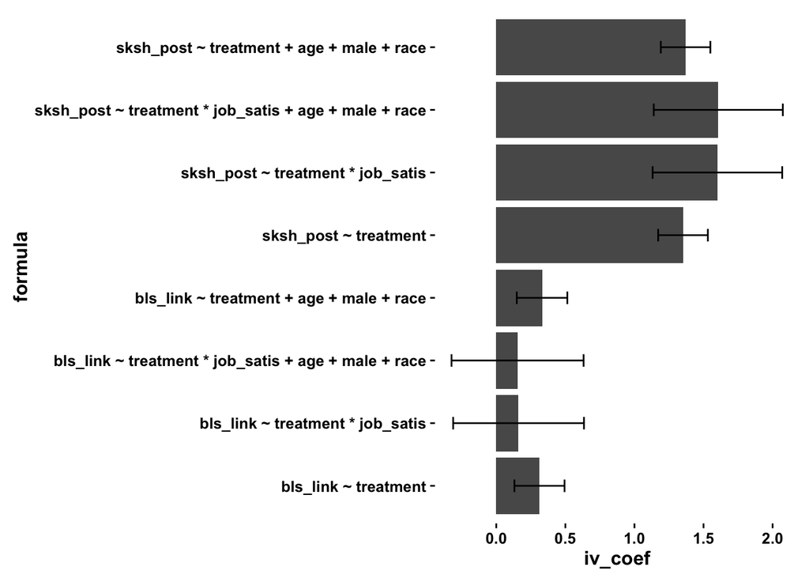

```r
# graph the coefficients of the iv with confidence intervals
ggplot(summary_df,
       aes(formula, iv_coef) ) +
    geom_bar( stat="summary", fun.y="mean", position=ug.dodge) +
    geom_errorbar(
        aes(ymax = iv_coef + 2 * iv_se, ymin=iv_coef - 2 * iv_se),
        position=ug.dodge,
        width=0.2
        ) +
    theme_classic() +
    theme(
        legend.key=element_rect(color="black",size=.5),
        axis.text=element_text(face="bold"),
        axis.title=element_text(face="bold")
    ) +
    coord_flip()
```

### Example of off-spec model

Note that `ds.summarize_glm1` only supports models that fit the ds.glm1 spec. It will issue warnings if invalid models are provided. In this example, condition is an invalid iv because it has multiple levels.

```r
dvs  = c("sksh_post") # dependent variables each run independently
ivs  = c("condition","treatment") # independent variables each run independently
mods = c("","job_satis")  # moderators each run independently, default no mod
cov_groups = list()  # vectors of covariates to run together
# covs = c()         # covariates included all together or none
                     # here, we use cov_groups instead for more flexibility


formulas <- ds.build_glm1_formulas(
                dvs=dvs, ivs=ivs, mods=mods, cov_groups = cov_groups
            )

models   <- ds.glm1s(formulas, data)
summary_df <- ds.get_model_summary_df(models, summary_func=ds.summarize_glm1)
```

ds.glm1 spec only allows ivs and moderators of type boolean or numeric. Supplied iv is: categorical in formula: sksh_post ~ condition

ds.glm1 spec only allows ivs and moderators of type boolean or numeric. Supplied iv is: categorical in formula: sksh_post ~ condition * job_satis

### Setting Contrasts

ds.glm1 spec only permits one contrast per variable. I.e., multi-level variables are not permitted in the IV or moderator. This choice reflects the desire to keep gymnast simple (for now) and also the desire be disciplined and thoughtful about how we set contrasts.

Here I show how condition could be coded two different ways to focus on specific contrasts.

```r
# there are several different conditions
data$condition %>% table %>% util.print_pre()
```

```
 .
  control     music    supply treatment
      460       339       339       803
```

```r
# set an overall treatment contrast
data$treatment_cont <- 0
data$treatment_cont[data$condition %in% "treatment"] <- .5
data$treatment_cont[!data$condition %in% "treatment"] <- -.5

# did the "supply" condition (an active control) improve outcomes
# relative to standard control?
data$supply_cont <- 0
data$supply_cont[data$condition %in% "control"] <- -.5
data$supply_cont[data$condition %in% "supply"] <- .5

table(data$supply_cont, data$condition) %>% util.print_pre()
```

```
       control music supply treatment
  -0.5     460     0      0         0
  0          0   339      0       803
  0.5        0     0    339         0
```

```r
summary_df <- ds.build_glm1_formulas(
                    dvs=dvs, ivs=c("treatment_cont","supply_cont"),
                    cov_groups = list("study_ID")
                ) %>%
                ds.glm1s(data=data) %>%
                ds.get_model_summary_df()

summary_df[ , c("formula","iv_apa") ] %>%
    util.html_table()
```

| formula | iv_apa |
| --- | --- |
| sksh_post ~ treatment_cont + study_ID | b=1.34, t(1119)=14.818, p<.001 |
| sksh_post ~ supply_cont + study_ID | b=-0.59, t(1119)=-2.997, p=0.003 |